# GM analysis: Preliminary results. Feb. 15 2020

Load data

```r
gmdata <- read.csv("DataSynthesis.csv",stringsAsFactors = F)
```

Load libraries

```r
library(ggplot2)
library(dplyr)
library(tidyr)
library(plotrix) #for std.error
library(EnvStats) #for gofTest
library(cowplot)
library(car)
library(faraway) #for gamma related things
```

theme_pub() for pretty figures

```r
theme_pub <- function (base_size = 12, base_family = "") {

  theme_classic(base_size = base_size, base_family = base_family) %+replace%

    theme(

      axis.text = element_text(colour = "black"),

      axis.title.x = element_text(size=16, margin=margin(t=5)),

      axis.text.x = element_text(size=10),

      axis.title.y = element_text(size=16,angle=90, margin=margin(r=5)),

      axis.text.y = element_text(size=10),

      axis.ticks = element_blank(),

      panel.background = element_rect(fill="white"),

      panel.border = element_blank(),

      plot.title=element_text(face="bold", size=20),

      legend.position="none"

    )

}
```

```r
#Assign family column
prefamily<-gsub("*.\\|","",gmdata$Tag)
gmdata$Family<-gsub("\\-.*","",prefamily)

#Filter out i Sample plants (not in competition experiment)... filtering i did not work, had to slice
gmdata <- slice(gmdata, -778:-952)

#What populations are in the experiment
unique(gmdata$Family)
```

```
 [1] "BWPEM1"  "CWRIC2"  "DVGM"    "EFCC2"   "JARI1"   "JBBLB2"  "JBCHY1"  "JWBOY"   "KVEDG1"
[10] "MAVBEL2" "MHBUR1"  "CBMCK1"  "MHNAT1"  "MSMID1"  "PDVRT1"  "RULEB1"  "SMAKC1"  "SMITH1"
[19] "VRCAN"   "CRSOSO"  "VRPET2"  "VSGARO1" "WSSWM3"  "pool"
```

Multiply gm leaf length and width to get leaf area

```r
gmdata <- gmdata %>% mutate(GM_LxW = GM_Leaf_Len * GM_Leaf_Wid)
```

Leaf size distribution

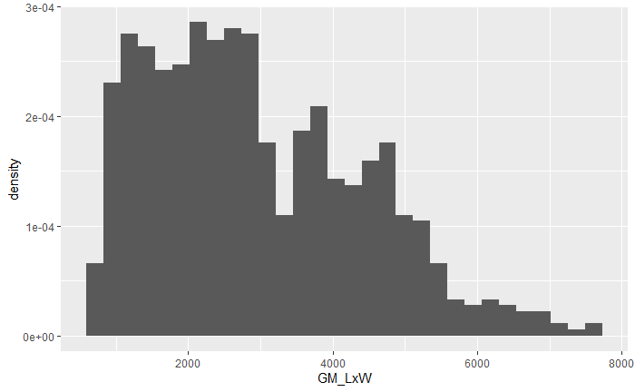

```r
ggplot(data = gmdata, aes(x = GM_LxW, y = ..density..))+
  geom_histogram()
```

See if leaf area and chemistry are correlated (pseudoreplicates still present)

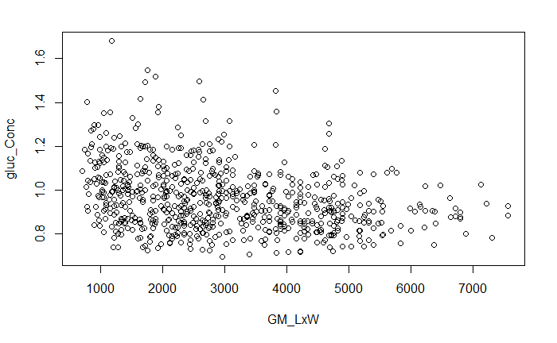

```r
plot(data = gmdata, gluc_Conc ~ GM_LxW)
abline(lm(gluc_Conc ~ GM_LxW, data = gmdata), na.rm = F)
```

```
Error in na.fail.default(list(gluc_Conc = c(0.779349194, 0.87443066815,  :
  missing values in object
```

Control for leaf size

[figure not shown]

Eliminate pseudoreplication by averaging values for leaves of the same plant

```r
PlantID
```

```
Error: object 'PlantID' not found
```

Merge data (leaf size manually controlled)

```r
gmdata2 <- merge(nopseudo, gmdata, by = "PlantID", all = TRUE)

goodvarbs <- c("PlantID", "Family", "treatment")
good <- gmdata %>% select(goodvarbs)

gmdata3 <- merge(good, nopseudo, by = "PlantID")

gmdata3 <- unique(gmdata3) #these are chemical values controlled for leaf size w family info

summary(gmdata3) #this includes pools
```

```
   PlantID             Family           treatment             mgluc            mflav
 Length:451         Length:451         Length:451         Min.   : 12.07   Min.   :12.17
 Class :character   Class :character   Class :character   1st Qu.: 33.06   1st Qu.:27.84
 Mode  :character   Mode  :character   Mode  :character   Median : 44.93   Median :38.74
                                                          Mean   : 45.76   Mean   :39.99
                                                          3rd Qu.: 57.32   3rd Qu.:49.39
                                                          Max.   :102.90   Max.   :95.04
                                                          NA's   :64       NA's   :79
     mchla            mchlb
 Min.   : 2.183   Min.   :-9.133
 1st Qu.: 9.935   1st Qu.: 3.576
 Median :13.985   Median : 5.082
 Mean   :16.083   Mean   : 5.750
 3rd Qu.:19.837   3rd Qu.: 7.389
 Max.   :65.203   Max.   :18.768
 NA's   :11       NA's   :11
```

```r
#exclude pools
gmdata3 <- gmdata3 %>% group_by(Family) %>% filter(!Family=="pool")
summary(gmdata3)
```

```
   PlantID             Family           treatment             mgluc            mflav
 Length:450         Length:450         Length:450         Min.   : 12.07   Min.   :12.17
 Class :character   Class :character   Class :character   1st Qu.: 33.06   1st Qu.:27.84
 Mode  :character   Mode  :character   Mode  :character   Median : 44.93   Median :38.74
                                                          Mean   : 45.76   Mean   :39.99
                                                          3rd Qu.: 57.32   3rd Qu.:49.39
                                                          Max.   :102.90   Max.   :95.04
                                                          NA's   :63       NA's   :78
     mchla            mchlb
 Min.   : 2.183   Min.   :-9.133
 1st Qu.: 9.935   1st Qu.: 3.576
 Median :13.985   Median : 5.082
 Mean   :16.083   Mean   : 5.750
 3rd Qu.:19.837   3rd Qu.: 7.389
 Max.   :65.203   Max.   :18.768
 NA's   :10       NA's   :10
```

```r
sum(!is.na(gmdata3$mgluc)) #387
```

```
[1] 387
```

```r
sum(!is.na(gmdata3$mflav)) #372
```

```
[1] 372
```

```r
sum(!is.na(gmdata3$mchla)) #440
```

```
[1] 440
```

```r
sum(!is.na(gmdata3$mchlb)) #440
```

```
[1] 440
```

NO MORE PSEUDOREP:

Plot controlled glucosinolate distribution

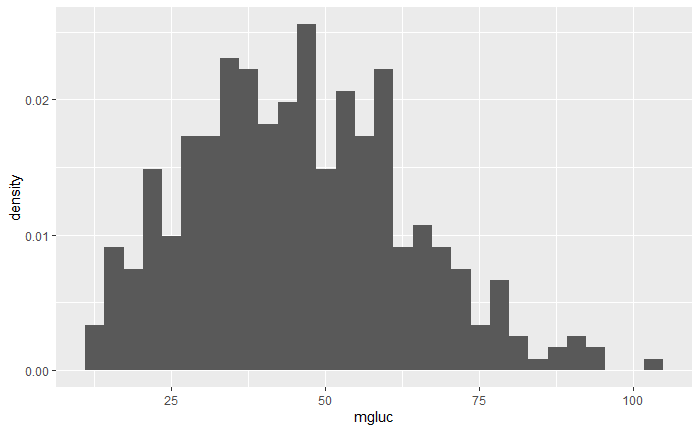

```r
ggplot(data = gmdata3, aes(x = mgluc, y = ..density..))+
  geom_histogram()
```

Graph chlorophyll a and b content against glucosinolate concentration for plants grown alone

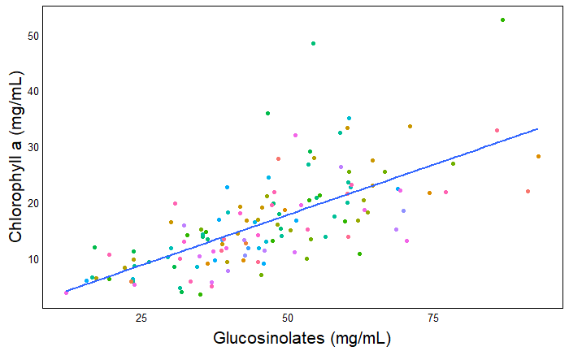

```r
#separate plants into alone treatment
ALN <- gmdata3[grepl("a",gmdata$treatment),]

#chlorophyll a
ggplot(data = ALN)+
  geom_point(aes(x = mgluc, y = mchla, colour = Family))+
  geom_smooth(aes(x = mgluc, y = mchla), method = "lm", se = FALSE)+
  scale_x_continuous(name = "Glucosinolates (mg/mL)")+
  scale_y_continuous(name = "Chlorophyll a (mg/mL)")+
  theme_pub()
```

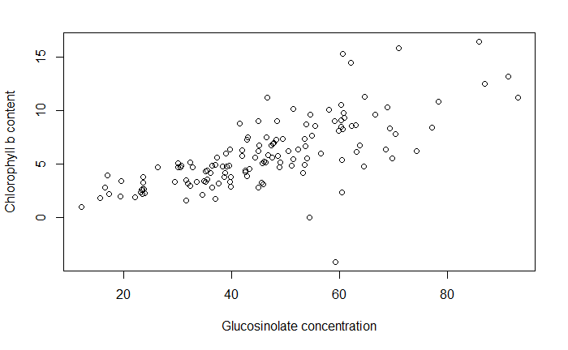

```r
#chlorophyll b
plot(ALN$mchlb ~ ALN$mgluc, data = ALN, xlab = "Glucosinolate concentration", ylab = "Chlorophyll b content")
```

```r
abline(lm(ALN$mchlb ~ ALN$mgluc, data = ALN))
```

```
Error in na.fail.default(list(`ALN$mchlb` = c(3.344822249, 9.0416736,  :
  missing values in object
```

Bivariate plots to look at plasticity and genetic variation

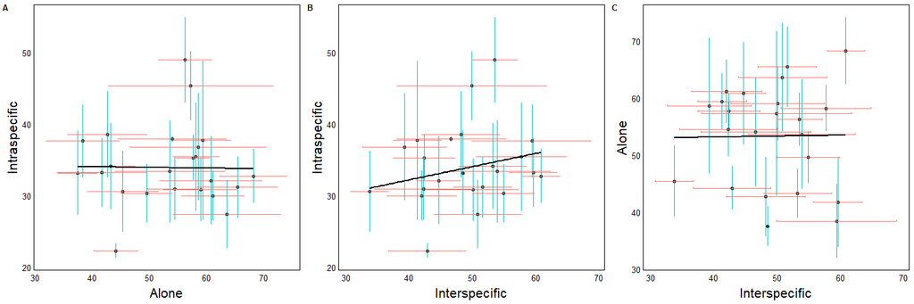

```r
#make a wide dataframe using 'spread'

widegm <- gmdata3 %>% spread(treatment, mgluc, fill = NA, convert = FALSE)
widegm <- widegm %>% mutate(meana = mean(a, na.rm = TRUE),
                            meangm = mean(gm, na.rm = T),
                            meanm = mean(m, na.rm = T))
widegm <- widegm %>% mutate(sea = std.error(a),
                            segm = std.error(gm),
                            sem = std.error(m))

########## BIVARIATE PLOTS ##########
### GLUC CONC ###
  #gm intra vs alone
p1 <- ggplot(data = widegm, aes(x = meana, y = meangm))+
  geom_point()+
  geom_errorbar(aes(ymin = meangm - segm,
                    ymax = meangm + segm,
                width = .000000000001, colour = "red"))+
  geom_errorbarh(aes(xmin = meana - sea,
                    xmax = meana + sea,
                    width = .000000000001, colour = "blue"))+
  geom_smooth(method = "lm", se = F, colour = "black")+
  labs(y = "Intraspecific", x = "Alone")+
  theme_pub()


  #gm intra vs m inter
p2 <- ggplot(data = widegm, aes(x = meanm, y = meangm))+
  geom_point()+
  geom_errorbar(aes(ymin = meangm - segm,
                    ymax = meangm + segm,
                width = .000000000001, colour = "red"))+
  geom_errorbarh(aes(xmin = meanm - sem,
                    xmax = meanm + sem,
                    width = .000000000001, colour = "blue"))+
  geom_smooth(method = "lm", se = F, colour = "black")+
  labs(y = "Intraspecific", x = "Interspecific")+
    theme_pub()


  #alone vs inter m
p3 <- ggplot(data = widegm, aes(x = meanm, y = meana))+
  geom_point()+
  geom_errorbar(aes(ymin = meana - sea,
                    ymax = meana + sea,
                width = .000000000001, colour ="red"))+
  geom_errorbarh(aes(xmin = meanm - sem,
                    xmax = meanm + sem,
                    width = .000000000001, colour = "blue"))+
  geom_smooth(method = "lm", se = F)+
  labs(y = "Alone", x = "Interspecific")+
  geom_smooth(method = "lm", se = F, colour = "black")+
  theme_pub()



plot_grid(p1, p2, p3, labels = c('A', 'B', 'C'), label_size = 10, ncol = 3)
```

Interaction plot

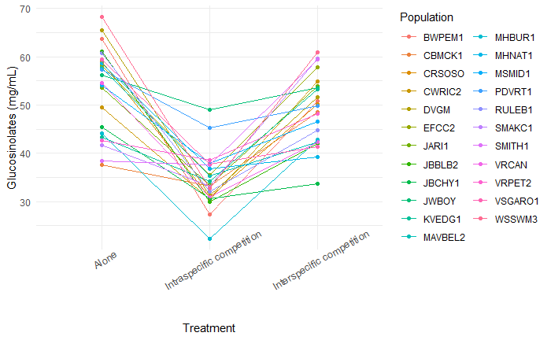

```r
ggplot(data = gmdata3, aes(x = treatment, y = mgluc, colour = Family, group = Family))+
  stat_summary(fun.y=mean, geom="point")+
  stat_summary(fun.y=mean, geom="line")+
  scale_colour_discrete(name = "Population")+
  scale_x_discrete(name = "Treatment",
                   labels = c("Alone", "Intraspecific competition", "Interspecific competition", "Pools"))+
  scale_y_continuous(name = "Glucosinolates (mg/mL)")+
  theme_minimal()+
  theme(axis.text.x = element_text(size = 10, angle=30))
```

Anova Testing for significant interactions between gluc conc, treatment, and family

```r
MyFit <- lm(gmdata3$mgluc ~ gmdata3$Family + gmdata3$treatment + gmdata3$Family:gmdata3$treatment, data = gmdata3)
```

```
Error in na.fail.default(list(`gmdata3$mgluc` = c(33.5769611081667, 53.2503834115581,  :
  missing values in object
```

```r
#test for normality
hist(residuals(MyFit),main="",xlab="Residuals", freq=FALSE)
```

```
Error in residuals(MyFit) : object 'MyFit' not found
```

ALTERNATIVE (not controlling manually for leaf size)

```r
#NOT CONTROLLED FOR LEAF SIZE
nopseudo1 <- gmdata %>% group_by(PlantID) %>%
  summarise(gluc = mean(gluc_Conc),
            flav = mean(flav_Conc),
            chla = mean(ChlorA),
            chlb = mean(ChlorB),
            leafa = mean(GM_LxW))
#merge

gm <- merge(nopseudo1, gmdata, by = "PlantID", all = TRUE)

goodvarbs <- c("PlantID", "Family", "treatment")
good <- gmdata %>% select(goodvarbs)

gm1 <- merge(good, nopseudo1, by = "PlantID")

gm1 <- unique(gm1)

summary(gm1) #this includes pools
```

```
   PlantID             Family           treatment              gluc             flav
 Length:451         Length:451         Length:451         Min.   :0.7407   Min.   :0.4585
 Class :character   Class :character   Class :character   1st Qu.:0.8671   1st Qu.:0.7429
 Mode  :character   Mode  :character   Mode  :character   Median :0.9555   Median :0.8510
                                                          Mean   :0.9636   Mean   :0.8527
                                                          3rd Qu.:1.0210   3rd Qu.:0.9550
                                                          Max.   :1.6824   Max.   :1.2946
                                                          NA's   :54       NA's   :69
      chla              chlb              leafa
 Min.   :0.07528   Min.   :-0.21978   Min.   : 783
 1st Qu.:0.24834   1st Qu.: 0.09109   1st Qu.:2096
 Median :0.33014   Median : 0.12003   Median :2750
 Mean   :0.35125   Mean   : 0.12339   Mean   :2878
 3rd Qu.:0.42416   3rd Qu.: 0.15233   3rd Qu.:3575
 Max.   :0.98593   Max.   : 0.38363   Max.   :6396
                                      NA's   :11
```

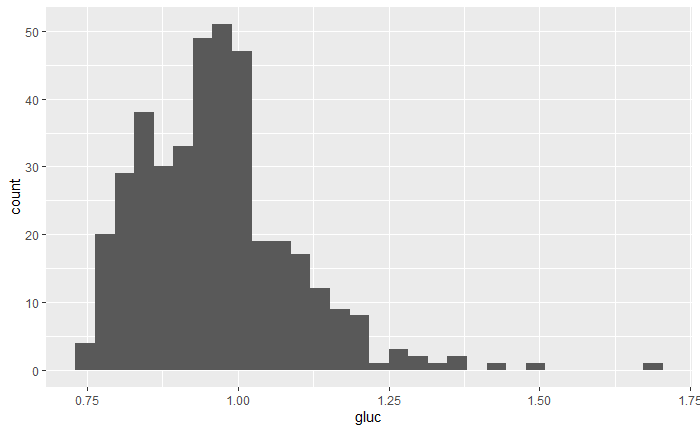

```r
#exclude pools
gm1 <- gm1 %>% group_by(Family) %>% filter(!Family=="pool")


ggplot(data = gm1, aes(x = gluc))+
  geom_histogram()
```

Model

```r
#trying out multiple regression model
summary(lmod <- lm(gluc ~ Family + treatment + leafa, data = gm1))
```

```
Error in na.fail.default(list(gluc = c(0.779349194, 0.9351373591625, 0.9091816214,  :
  missing values in object
```

graphs

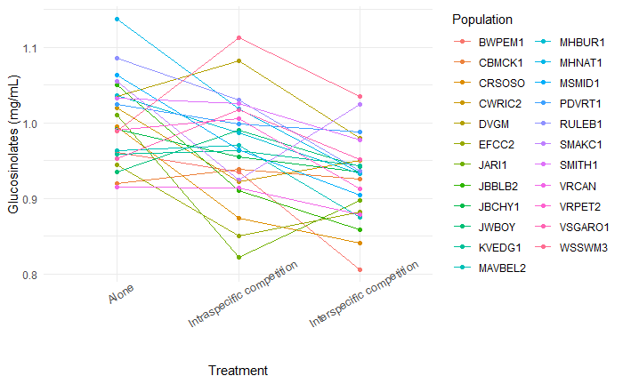

```r
#gluc
ggplot(data = gm1, aes(x = treatment, y = gluc, colour = Family, group = Family))+
  stat_summary(fun.y=mean, geom="point")+
  stat_summary(fun.y=mean, geom="line")+
  scale_colour_discrete(name = "Population")+
  scale_x_discrete(name = "Treatment",
                   labels = c("Alone", "Intraspecific competition", "Interspecific competition", "Pools"))+
  scale_y_continuous(name = "Glucosinolates (mg/mL)")+
  theme_minimal()+
  theme(axis.text.x = element_text(size = 10, angle=30))
```

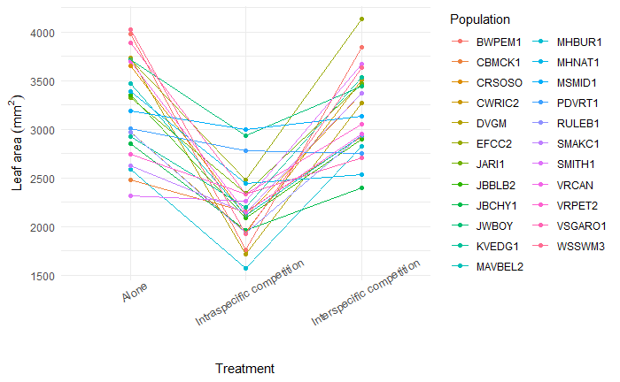

```r
#leaf size
ggplot(data = gm1, aes(x = treatment, y = leafa, colour = Family, group = Family))+
  stat_summary(fun.y=mean, geom="point")+
  stat_summary(fun.y=mean, geom="line")+
  scale_colour_discrete(name = "Population")+
  scale_x_discrete(name = "Treatment",
                   labels = c("Alone", "Intraspecific competition", "Interspecific competition", "Pools"))+
  scale_y_continuous(name = expression(paste("Leaf area ", (mm^2),"")))+
  theme_minimal()+
  theme(axis.text.x = element_text(size = 10, angle=30))
```

Compare gluc with and without controlling for leaf size

```
Removed 53 rows containing non-finite values (stat_summary).Removed 53 rows containing non-finite values (stat_summary).Removed 63 rows containing non-finite values (stat_summary).Removed 63 rows containing non-finite values (stat_summary).
```

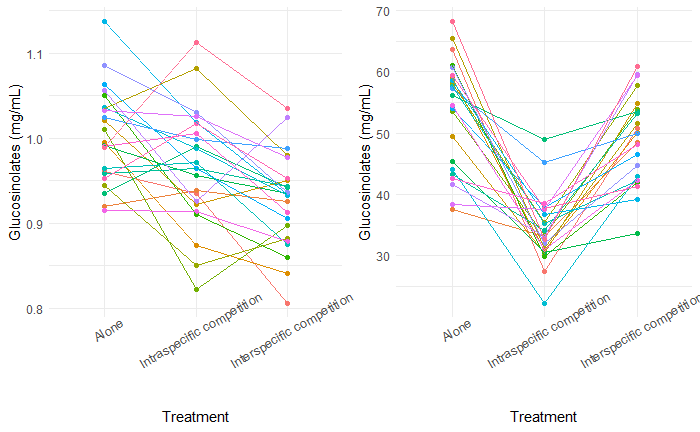

```r
g1 <- ggplot(data = gm1, aes(x = treatment, y = gluc, colour = Family, group = Family))+
  stat_summary(fun.y=mean, geom="point")+
  stat_summary(fun.y=mean, geom="line")+
  scale_colour_discrete(name = "Population")+
  scale_x_discrete(name = "Treatment",
                   labels = c("Alone", "Intraspecific competition", "Interspecific competition", "Pools"))+
  scale_y_continuous(name = "Glucosinolates (mg/mL)")+
  theme_minimal()+
  theme(axis.text.x = element_text(size = 10, angle=30), legend.position = "none")

gcon <- ggplot(data = gmdata3, aes(x = treatment, y = mgluc, colour = Family, group = Family))+
  stat_summary(fun.y=mean, geom="point")+
  stat_summary(fun.y=mean, geom="line")+
  scale_colour_discrete(name = "Population")+
  scale_x_discrete(name = "Treatment",
                   labels = c("Alone", "Intraspecific competition", "Interspecific competition", "Pools"))+
  scale_y_continuous(name = "Glucosinolates (mg/mL)")+
  theme_minimal()+
  theme(axis.text.x = element_text(size = 10, angle=30), legend.position = "none")


plot_grid(g1, gcon)
```

Compare (gluc controlling for leaf size) and (leaf size)

```
Removed 63 rows containing non-finite values (stat_summary).Removed 63 rows containing non-finite values (stat_summary).Removed 10 rows containing non-finite values (stat_summary).Removed 10 rows containing non-finite values (stat_summary).
```

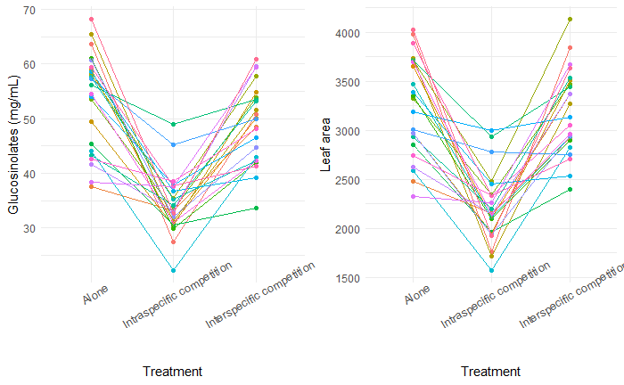

```r
leaf <- ggplot(data = gm1, aes(x = treatment, y = leafa, colour = Family, group = Family))+
  stat_summary(fun.y=mean, geom="point")+
  stat_summary(fun.y=mean, geom="line")+
  scale_colour_discrete(name = "Population")+
  scale_x_discrete(name = "Treatment",
                   labels = c("Alone", "Intraspecific competition", "Interspecific competition", "Pools"))+
  scale_y_continuous(name = "Leaf area")+
  theme_minimal()+
  theme(axis.text.x = element_text(size = 10, angle=30),
        legend.position = "none")

plot_grid(gcon, leaf)
```

Gluc and leaf correlation (duplicates removed, no control for leaf size)

[figure not shown]

```r
MyFit2 <- lm(gm1$leafa ~ gm1$Family + gm1$treatment + gm1$Family:gm1$treatment, data = gm1)
summary(aov(MyFit))
```

```
                                  Df Sum Sq Mean Sq F value Pr(>F)
gmdata3$Family                    22   8485     386   1.768 0.0192 *
gmdata3$treatment                  2  26851   13425  61.531 <2e-16 ***
gmdata3$Family:gmdata3$treatment  44  11852     269   1.235 0.1571
Residuals                        318  69384     218
---
Signif. codes:  0 ‘***’ 0.001 ‘**’ 0.01 ‘*’ 0.05 ‘.’ 0.1 ‘ ’ 1
63 observations deleted due to missingness
```

```r
summary(lm(chla ~ gluc, data = gm1))
```

```
Call:
lm(formula = chla ~ gluc, data = gm1)

Residuals:
     Min       1Q   Median       3Q      Max
-0.39642 -0.07731 -0.01322  0.06462  0.46084

Coefficients:
            Estimate Std. Error t value Pr(>|t|)
(Intercept) -0.37856    0.04555  -8.311 1.54e-15 ***
gluc         0.76138    0.04686  16.246  < 2e-16 ***
---
Signif. codes:  0 ‘***’ 0.001 ‘**’ 0.01 ‘*’ 0.05 ‘.’ 0.1 ‘ ’ 1

Residual standard error: 0.1182 on 395 degrees of freedom
  (53 observations deleted due to missingness)
Multiple R-squared:  0.4006,    Adjusted R-squared:  0.399
F-statistic: 263.9 on 1 and 395 DF,  p-value: < 2.2e-16
```

Leaf size

```r
pairs(z.em, adjust = "tukey")
```

```
 contrast estimate  SE  df t.ratio p.value
 a - gm     1077.2 114 437  9.445  <.0001
 a - m        34.8 114 437  0.305  0.9499
 gm - m    -1042.4 113 437 -9.187  <.0001

P value adjustment: tukey method for comparing a family of 3 estimates
```

bivariate plot for gluc w/out controlling for leaf size

[figure not shown]

2 way anova w/out control for leaf size

```r
summary(aov(MyFit3))
```

```
                          Df Sum Sq Mean Sq F value   Pr(>F)
gm1$Family                22  0.714 0.03244   2.244  0.00132 **
gm1$treatment              2  0.350 0.17503  12.105 8.47e-06 ***
gm1$Family:gm1$treatment  44  0.550 0.01251   0.865  0.71503
Residuals                328  4.743 0.01446
---
Signif. codes:  0 ‘***’ 0.001 ‘**’ 0.01 ‘*’ 0.05 ‘.’ 0.1 ‘ ’ 1
53 observations deleted due to missingness
```